# Cars4U Project

## Context

Cars4U is tech start-up which is aiming to establish itself in the pre-owned car market. The organization is analyzing a data set to predict the price of used cars, and generate some business insights.

## Objective

Develop a pricing model (using linear regression) of used cars , based on the independent variables as provided in the data set.

## Data Description

The data contains information about the used cars sold in different locations.

## Data Dictionary

- S.No.: Serial number
- Name: Name of the car which includes brand name and model name
- Location: Location in which the car is being sold or is available for purchase (cities)
- Year: Manufacturing year of the car
- Kilometers_driven: The total kilometers driven in the car by the previous owner(s) in km
- Fuel_Type: The type of fuel used by the car (Petrol, Diesel, Electric, CNG, LPG)
- Transmission: The type of transmission used by the car (Automatic/Manual)
- Owner: Type of ownership
- Mileage: The standard mileage offered by the car company in kmpl or km/kg
- Engine: The displacement volume of the engine in CC
- Power: The maximum power of the engine in bhp
- Seats: The number of seats in the car
- New_Price: The price of a new car of the same model in INR Lakhs (1 Lakh INR = 100,000 INR)
- Price: The price of the used car in INR Lakhs

### Import necessary libraries

```python
# Libraries to help with reading and manipulating data
import numpy as np
import pandas as pd

# Libraries to help with data visualization
import matplotlib.pyplot as plt
import seaborn as sns

sns.set()

import warnings

warnings.filterwarnings("ignore")

# Removes the limit for the number of displayed columns
pd.set_option("display.max_columns", None)
# Sets the limit for the number of displayed rows
pd.set_option("display.max_rows", 200)

# to split the data into train and test
from sklearn.model_selection import train_test_split

# to build linear regression_model
from sklearn.linear_model import LinearRegression

# to check model performance
from sklearn.metrics import mean_absolute_error, mean_squared_error, r2_score

# this will help in making the Python code more structured automatically (good coding practice)
#following line is commented, as the nb_black extension is already loaded (to prevent the error)
#%load_ext nb_black
```

```python
# loading the dataset
data1 = pd.read_csv("used_cars_data.csv")
```

### Initial Analysis of data

```python
# checking the shape of the data
print(f"There are {data1.shape[0]} rows and {data1.shape[1]} columns.")  # f-string
```

```
There are 7253 rows and 14 columns.
```

```python
# let's view a sample of the data
data1.sample(
    10, random_state=1
)  # setting the random_state will ensure we get the same results every time
```

|  | S.No. | Name | Location | Year | Kilometers_Driven | Fuel_Type | Transmission | Owner_Type | Mileage | Engine | Power | Seats | New_Price | Price |
| --- | --- | --- | --- | --- | --- | --- | --- | --- | --- | --- | --- | --- | --- | --- |
| 2397 | 2397 | Ford EcoSport 1.5 Petrol Trend | Kolkata | 2016 | 21460 | Petrol | Manual | First | 17.0 kmpl | 1497 CC | 121.36 bhp | 5.0 | 9.47 Lakh | 6.00 |
| 3777 | 3777 | Maruti Wagon R VXI 1.2 | Kochi | 2015 | 49818 | Petrol | Manual | First | 21.5 kmpl | 1197 CC | 81.80 bhp | 5.0 | 5.44 Lakh | 4.11 |
| 4425 | 4425 | Ford Endeavour 4x2 XLT | Hyderabad | 2007 | 130000 | Diesel | Manual | First | 13.1 kmpl | 2499 CC | 141 bhp | 7.0 | NaN | 6.00 |
| 3661 | 3661 | Mercedes-Benz E-Class E250 CDI Avantgrade | Coimbatore | 2016 | 39753 | Diesel | Automatic | First | 13.0 kmpl | 2143 CC | 201.1 bhp | 5.0 | NaN | 35.28 |
| 4514 | 4514 | Hyundai Xcent 1.2 Kappa AT SX Option | Kochi | 2016 | 45560 | Petrol | Automatic | First | 16.9 kmpl | 1197 CC | 82 bhp | 5.0 | NaN | 6.34 |
| 599 | 599 | Toyota Innova Crysta 2.8 ZX AT | Coimbatore | 2019 | 40674 | Diesel | Automatic | First | 11.36 kmpl | 2755 CC | 171.5 bhp | 7.0 | 28.05 Lakh | 24.82 |
| 186 | 186 | Mercedes-Benz E-Class E250 CDI Avantgrade | Bangalore | 2014 | 37382 | Diesel | Automatic | First | 13.0 kmpl | 2143 CC | 201.1 bhp | 5.0 | NaN | 32.00 |
| 305 | 305 | Audi A6 2011-2015 2.0 TDI Premium Plus | Kochi | 2014 | 61726 | Diesel | Automatic | First | 17.68 kmpl | 1968 CC | 174.33 bhp | 5.0 | NaN | 20.77 |
| 4582 | 4582 | Hyundai i20 1.2 Magna | Kolkata | 2011 | 36000 | Petrol | Manual | First | 18.5 kmpl | 1197 CC | 80 bhp | 5.0 | NaN | 2.50 |
| 5434 | 5434 | Honda WR-V Edge Edition i-VTEC S | Kochi | 2019 | 13913 | Petrol | Manual | First | 17.5 kmpl | 1199 CC | 88.7 bhp | 5.0 | 9.36 Lakh | 8.20 |

```python
# Copying the data to a dataframe named df
df = data1.copy()
```

```python
# Check for any duplicate rows
df.duplicated().sum()
```

```
0
```

```python
# checking column datatypes and number of non-null values
df.info()
```

```
<class 'pandas.core.frame.DataFrame'>
RangeIndex: 7253 entries, 0 to 7252
Data columns (total 14 columns):
 #   Column             Non-Null Count  Dtype
---  ------             --------------  -----
 0   S.No.              7253 non-null   int64
 1   Name               7253 non-null   object
 2   Location           7253 non-null   object
 3   Year               7253 non-null   int64
 4   Kilometers_Driven  7253 non-null   int64
 5   Fuel_Type          7253 non-null   object
 6   Transmission       7253 non-null   object
 7   Owner_Type         7253 non-null   object
 8   Mileage            7251 non-null   object
 9   Engine             7207 non-null   object
 10  Power              7078 non-null   object
 11  Seats              7200 non-null   float64
 12  New_Price          1006 non-null   object
 13  Price              6019 non-null   float64
dtypes: float64(2), int64(3), object(9)
memory usage: 793.4+ KB
```

```python
# checking for missing values in descending order
df.isnull().sum().sort_values(ascending=False)
```

```
New_Price            6247
Price                1234
Power                 175
Seats                  53
Engine                 46
Mileage                 2
S.No.                   0
Name                    0
Location                0
Year                    0
Kilometers_Driven       0
Fuel_Type               0
Transmission            0
Owner_Type              0
dtype: int64
```

#### Observation : New_price is the column with largest missing values, followed by Price, Power, Seats, Engine and Mileage

### Summary of the dataset

```python
df.describe(include="all").T
```

|  | count | unique | top | freq | mean | std | min | 25% | 50% | 75% | max |
| --- | --- | --- | --- | --- | --- | --- | --- | --- | --- | --- | --- |
| S.No. | 7253.0 | NaN | NaN | NaN | 3626.0 | 2093.905084 | 0.0 | 1813.0 | 3626.0 | 5439.0 | 7252.0 |
| Name | 7253 | 2041 | Mahindra XUV500 W8 2WD | 55 | NaN | NaN | NaN | NaN | NaN | NaN | NaN |
| Location | 7253 | 11 | Mumbai | 949 | NaN | NaN | NaN | NaN | NaN | NaN | NaN |
| Year | 7253.0 | NaN | NaN | NaN | 2013.365366 | 3.254421 | 1996.0 | 2011.0 | 2014.0 | 2016.0 | 2019.0 |
| Kilometers_Driven | 7253.0 | NaN | NaN | NaN | 58699.063146 | 84427.720583 | 171.0 | 34000.0 | 53416.0 | 73000.0 | 6500000.0 |
| Fuel_Type | 7253 | 5 | Diesel | 3852 | NaN | NaN | NaN | NaN | NaN | NaN | NaN |
| Transmission | 7253 | 2 | Manual | 5204 | NaN | NaN | NaN | NaN | NaN | NaN | NaN |
| Owner_Type | 7253 | 4 | First | 5952 | NaN | NaN | NaN | NaN | NaN | NaN | NaN |
| Mileage | 7251 | 450 | 17.0 kmpl | 207 | NaN | NaN | NaN | NaN | NaN | NaN | NaN |
| Engine | 7207 | 150 | 1197 CC | 732 | NaN | NaN | NaN | NaN | NaN | NaN | NaN |
| Power | 7078 | 385 | 74 bhp | 280 | NaN | NaN | NaN | NaN | NaN | NaN | NaN |
| Seats | 7200.0 | NaN | NaN | NaN | 5.279722 | 0.81166 | 0.0 | 5.0 | 5.0 | 5.0 | 10.0 |
| New_Price | 1006 | 625 | 4.78 Lakh | 6 | NaN | NaN | NaN | NaN | NaN | NaN | NaN |
| Price | 6019.0 | NaN | NaN | NaN | 9.479468 | 11.187917 | 0.44 | 3.5 | 5.64 | 9.95 | 160.0 |

#### Observation

- Mahindra XUV500 W8 2WD is the top selling car
- There are 5 different fuel types (Diesel is the most common)
- There are 4 different owner types. (First is the most common)
- There are 2 different Transmission types (Manual is the most common)
- Price varying from 0.44 to 160 Lakhs (INR)
- Mumbai is the top location

### Data Pre-Processing

```python
# Dropping S.No. column as it is not important in processing the data for linear regression
df.drop(["S.No."], axis=1, inplace=True)
```

```python
# Dropping the null rows in the Price column, as it is the target variable
df.dropna(subset=["Price"], inplace=True)
df.info()
```

```
<class 'pandas.core.frame.DataFrame'>
Int64Index: 6019 entries, 0 to 6018
Data columns (total 13 columns):
 #   Column             Non-Null Count  Dtype
---  ------             --------------  -----
 0   Name               6019 non-null   object
 1   Location           6019 non-null   object
 2   Year               6019 non-null   int64
 3   Kilometers_Driven  6019 non-null   int64
 4   Fuel_Type          6019 non-null   object
 5   Transmission       6019 non-null   object
 6   Owner_Type         6019 non-null   object
 7   Mileage            6017 non-null   object
 8   Engine             5983 non-null   object
 9   Power              5876 non-null   object
 10  Seats              5977 non-null   float64
 11  New_Price          824 non-null    object
 12  Price              6019 non-null   float64
dtypes: float64(2), int64(2), object(9)
memory usage: 658.3+ KB
```

#### Observation: 1234 rows are deleted where Price is null . Resulting dataset has 6019 rows

```python
# checking again for missing values in descending order
df.isnull().sum().sort_values(ascending=False)
```

```
New_Price            5195
Power                 143
Seats                  42
Engine                 36
Mileage                 2
Name                    0
Location                0
Year                    0
Kilometers_Driven       0
Fuel_Type               0
Transmission            0
Owner_Type              0
Price                   0
dtype: int64
```

### Stripping the units from 3 columns

```python
# Checking the rows before applying the strip function
strip_cols = ["Engine", "Mileage", "Power"]
df[strip_cols].sample(10, random_state=1)
```

|  | Engine | Mileage | Power |
| --- | --- | --- | --- |
| 2319 | 2987 CC | 18.0 kmpl | 258 bhp |
| 3652 | 1586 CC | 15.6 kmpl | 104.68 bhp |
| 2397 | 1497 CC | 17.0 kmpl | 121.36 bhp |
| 3536 | 1497 CC | 16.8 kmpl | 116.3 bhp |
| 4400 | 1598 CC | 15.26 kmpl | 103.5 bhp |
| 5347 | 796 CC | 24.7 kmpl | 47.3 bhp |
| 2852 | 2147 CC | 15.0 kmpl | 107.3 bhp |
| 4894 | 1248 CC | 27.39 kmpl | 74 bhp |
| 1897 | 1461 CC | 21.64 kmpl | 84.8 bhp |
| 3663 | 1120 CC | 24.4 kmpl | 71 bhp |

```python
# Stripping the units from columns Mileage, Engine, Power , also converting to a float data type


def strip_units(val):
    """This function takes in a string and strips the unit strings like CC, kmpl and bhp.
    If the input is not string this function just returns np.nan."""
    if isinstance(val, str):  # checks if `income_val` is a string
        if val.endswith("CC"):
            return float(val.replace("CC", ""))

        if val.endswith("bhp"):
            return float(val.replace("bhp", ""))

        if val.endswith("kmpl"):
            return float(val.replace("kmpl", ""))

        if val.endswith("km/kg"):
            return float(val.replace("km/kg", ""))

    else:  # this happens when the current string is np.nan
        return np.nan


for colname in strip_cols:
    df[colname] = df[colname].apply(strip_units)

df[strip_cols].sample(10, random_state=1)
```

|  | Engine | Mileage | Power |
| --- | --- | --- | --- |
| 2319 | 2987.0 | 18.00 | 258.00 |
| 3652 | 1586.0 | 15.60 | 104.68 |
| 2397 | 1497.0 | 17.00 | 121.36 |
| 3536 | 1497.0 | 16.80 | 116.30 |
| 4400 | 1598.0 | 15.26 | 103.50 |
| 5347 | 796.0 | 24.70 | 47.30 |
| 2852 | 2147.0 | 15.00 | 107.30 |
| 4894 | 1248.0 | 27.39 | 74.00 |
| 1897 | 1461.0 | 21.64 | 84.80 |
| 3663 | 1120.0 | 24.40 | 71.00 |

### Stripping the New Price from Lakhs and Cr , and also converting Cr to Lakhs

```python
price_cols = ["New_Price"]


def cr_to_lakh(price_val):
    """This function takes in a string of price
    and converts it to a number. Also converts crore to Lakhs by using a multiplier 100.
    If the input is already numeric, which probably means it's NaN,
    this function just returns np.nan."""
    if isinstance(price_val, str):  # checks if `price_val` is a string

        if price_val.endswith("Cr"):
            multiplier = 100
            return float(price_val.replace("Cr", "")) * multiplier
        if price_val.endswith("Lakh"):
            return float(price_val.replace("Lakh", ""))
        # this happens when the price is np.nan
        return np.nan


for colname in price_cols:
    df[colname] = df[colname].apply(cr_to_lakh)

df[price_cols].head()
```

|  | New_Price |
| --- | --- |
| 0 | NaN |
| 1 | NaN |
| 2 | 8.61 |
| 3 | NaN |
| 4 | NaN |

```python
df.info()
```

```
<class 'pandas.core.frame.DataFrame'>
Int64Index: 6019 entries, 0 to 6018
Data columns (total 13 columns):
 #   Column             Non-Null Count  Dtype
---  ------             --------------  -----
 0   Name               6019 non-null   object
 1   Location           6019 non-null   object
 2   Year               6019 non-null   int64
 3   Kilometers_Driven  6019 non-null   int64
 4   Fuel_Type          6019 non-null   object
 5   Transmission       6019 non-null   object
 6   Owner_Type         6019 non-null   object
 7   Mileage            6017 non-null   float64
 8   Engine             5983 non-null   float64
 9   Power              5876 non-null   float64
 10  Seats              5977 non-null   float64
 11  New_Price          824 non-null    float64
 12  Price              6019 non-null   float64
dtypes: float64(6), int64(2), object(5)
memory usage: 658.3+ KB
```

***Observations:

```
- Mileage, Engine, Power, New_Price are converted to float data types***
```

```python
df.sample(10, random_state=1)
```

|  | Name | Location | Year | Kilometers_Driven | Fuel_Type | Transmission | Owner_Type | Mileage | Engine | Power | Seats | New_Price | Price |
| --- | --- | --- | --- | --- | --- | --- | --- | --- | --- | --- | --- | --- | --- |
| 2319 | Mercedes-Benz E-Class E 350 d | Coimbatore | 2019 | 9312 | Diesel | Automatic | First | 18.00 | 2987.0 | 258.00 | 5.0 | 92.50 | 78.80 |
| 3652 | Maruti SX4 Zxi with Leather BSIII | Coimbatore | 2008 | 77325 | Petrol | Manual | First | 15.60 | 1586.0 | 104.68 | 5.0 | NaN | 3.51 |
| 2397 | Ford EcoSport 1.5 Petrol Trend | Kolkata | 2016 | 21460 | Petrol | Manual | First | 17.00 | 1497.0 | 121.36 | 5.0 | 9.47 | 6.00 |
| 3536 | Honda City V MT | Kochi | 2018 | 11966 | Petrol | Manual | First | 16.80 | 1497.0 | 116.30 | 5.0 | NaN | 10.28 |
| 4400 | Volkswagen Polo Petrol Highline 1.6L | Kolkata | 2011 | 46000 | Petrol | Manual | First | 15.26 | 1598.0 | 103.50 | 5.0 | NaN | 2.35 |
| 5347 | Maruti Alto 800 2016-2019 LXI | Mumbai | 2018 | 11000 | Petrol | Manual | First | 24.70 | 796.0 | 47.30 | 5.0 | NaN | 3.35 |
| 2852 | Mercedes-Benz B Class 2012-2015 B200 Sport CDI | Bangalore | 2014 | 36000 | Diesel | Automatic | First | 15.00 | 2147.0 | 107.30 | 5.0 | NaN | 16.25 |
| 4894 | Maruti Baleno Alpha Diesel | Hyderabad | 2017 | 24000 | Diesel | Manual | First | 27.39 | 1248.0 | 74.00 | 5.0 | 10.63 | 8.40 |
| 1897 | Renault Scala Diesel RxL | Kolkata | 2013 | 40000 | Diesel | Manual | First | 21.64 | 1461.0 | 84.80 | 5.0 | NaN | 4.00 |
| 3663 | Hyundai Xcent 1.1 CRDi Base | Pune | 2017 | 73000 | Diesel | Manual | First | 24.40 | 1120.0 | 71.00 | 5.0 | NaN | 4.50 |

```python
# Dropping New_Price column as it is not easy to impute the variable with almost 80% as null
df.drop(["New_Price"], axis=1, inplace=True)
```

```python
# checking again for missing values in descending order
df.isnull().sum().sort_values(ascending=False)
```

```
Power                143
Seats                 42
Engine                36
Mileage                2
Name                   0
Location               0
Year                   0
Kilometers_Driven      0
Fuel_Type              0
Transmission           0
Owner_Type             0
Price                  0
dtype: int64
```

### Summary Statistics of numerical variables

```python
df.describe().T
```

|  | count | mean | std | min | 25% | 50% | 75% | max |
| --- | --- | --- | --- | --- | --- | --- | --- | --- |
| Year | 6019.0 | 2013.358199 | 3.269742 | 1998.00 | 2011.00 | 2014.00 | 2016.00 | 2019.00 |
| Kilometers_Driven | 6019.0 | 58738.380296 | 91268.843206 | 171.00 | 34000.00 | 53000.00 | 73000.00 | 6500000.00 |
| Mileage | 6017.0 | 18.134961 | 4.582289 | 0.00 | 15.17 | 18.15 | 21.10 | 33.54 |
| Engine | 5983.0 | 1621.276450 | 601.355233 | 72.00 | 1198.00 | 1493.00 | 1984.00 | 5998.00 |
| Power | 5876.0 | 113.253050 | 53.874957 | 34.20 | 75.00 | 97.70 | 138.10 | 560.00 |
| Seats | 5977.0 | 5.278735 | 0.808840 | 0.00 | 5.00 | 5.00 | 5.00 | 10.00 |
| Price | 6019.0 | 9.479468 | 11.187917 | 0.44 | 3.50 | 5.64 | 9.95 | 160.00 |

## Missing Value Treatment

### Finding the records with mileage as null

```python
mileage_zero = pd.isnull(df["Mileage"]) # find rows where Mileage is null
df[mileage_zero]
```

|  | Name | Location | Year | Kilometers_Driven | Fuel_Type | Transmission | Owner_Type | Mileage | Engine | Power | Seats | Price |
| --- | --- | --- | --- | --- | --- | --- | --- | --- | --- | --- | --- | --- |
| 4446 | Mahindra E Verito D4 | Chennai | 2016 | 50000 | Electric | Automatic | First | NaN | 72.0 | 41.0 | 5.0 | 13.00 |
| 4904 | Toyota Prius 2009-2016 Z4 | Mumbai | 2011 | 44000 | Electric | Automatic | First | NaN | 1798.0 | 73.0 | 5.0 | 12.75 |

*Observation: Two rows with mileage as null, are both Electric vehicles(Fuel type) these 2 rows are removed because they are the only electric vehicles in the dataset*

```python
df.dropna(subset=["Mileage"], inplace=True) # Dropped the 2 rows where Mileage is null
df.isnull().sum().sort_values(ascending=False)
```

```
Power                143
Seats                 42
Engine                36
Name                   0
Location               0
Year                   0
Kilometers_Driven      0
Fuel_Type              0
Transmission           0
Owner_Type             0
Mileage                0
Price                  0
dtype: int64
```

*Observation: Resulting dataset has 6017 rows*

### Impute variables with Mean /Median for Engine, Power and Seats

```python
# Copying the df dataframe to a new dataframe df2
df2 = df.copy()
df2["Engine"].fillna(df2.Engine.median(), inplace=True)
df2["Power"].fillna(df2.Power.median(), inplace=True)
df2["Seats"].fillna(df2.Seats.median(), inplace=True)
df2.describe().T
```

|  | count | mean | std | min | 25% | 50% | 75% | max |
| --- | --- | --- | --- | --- | --- | --- | --- | --- |
| Year | 6017.0 | 2013.358152 | 3.269967 | 1998.00 | 2011.00 | 2014.00 | 2016.00 | 2019.00 |
| Kilometers_Driven | 6017.0 | 58742.282034 | 91283.745583 | 171.00 | 34000.00 | 53000.00 | 73000.00 | 6500000.00 |
| Mileage | 6017.0 | 18.134961 | 4.582289 | 0.00 | 15.17 | 18.15 | 21.10 | 33.54 |
| Engine | 6017.0 | 1620.737078 | 599.398319 | 624.00 | 1198.00 | 1493.00 | 1969.00 | 5998.00 |
| Power | 6017.0 | 112.902114 | 53.282014 | 34.20 | 78.00 | 97.70 | 138.03 | 560.00 |
| Seats | 6017.0 | 5.276882 | 0.806464 | 0.00 | 5.00 | 5.00 | 5.00 | 10.00 |
| Price | 6017.0 | 9.478340 | 11.189605 | 0.44 | 3.50 | 5.64 | 9.95 | 160.00 |

### Observations

- Missing values is now filled with median value. The mean and std values are not modified much.
- All 6017 rows have each of the columns now populated with values

## Univariate Analysis

```python
# This function takes the numerical column as the input and returns the boxplots and histograms for the variable.
# Let us see if this helps us write faster and cleaner code.


def histogram_boxplot(feature, figsize=(15, 10), bins=None):
    """Boxplot and histogram combined
    feature: 1-d feature array
    figsize: size of fig (default (9,8))
    bins: number of bins (default None / auto)
    """
    f2, (ax_box2, ax_hist2) = plt.subplots(
        nrows=2,  # Number of rows of the subplot grid= 2
        sharex=True,  # x-axis will be shared among all subplots
        gridspec_kw={"height_ratios": (0.25, 0.75)},
        figsize=figsize,
    )  # creating the 2 subplots
    sns.boxplot(
        feature, ax=ax_box2, showmeans=True, color="violet"
    )  # boxplot will be created and a star will indicate the mean value of the column
    sns.histplot(
        feature, kde=F, ax=ax_hist2, bins=bins, palette="winter"
    ) if bins else sns.distplot(
        feature, kde=False, ax=ax_hist2
    )  # For histogram
    ax_hist2.axvline(
        feature.mean(), color="green", linestyle="--"
    )  # Add mean to the histogram
    ax_hist2.axvline(
        feature.median(), color="black", linestyle="-"
    )  # Add median to the histogram
```

### Price (Target Variable)

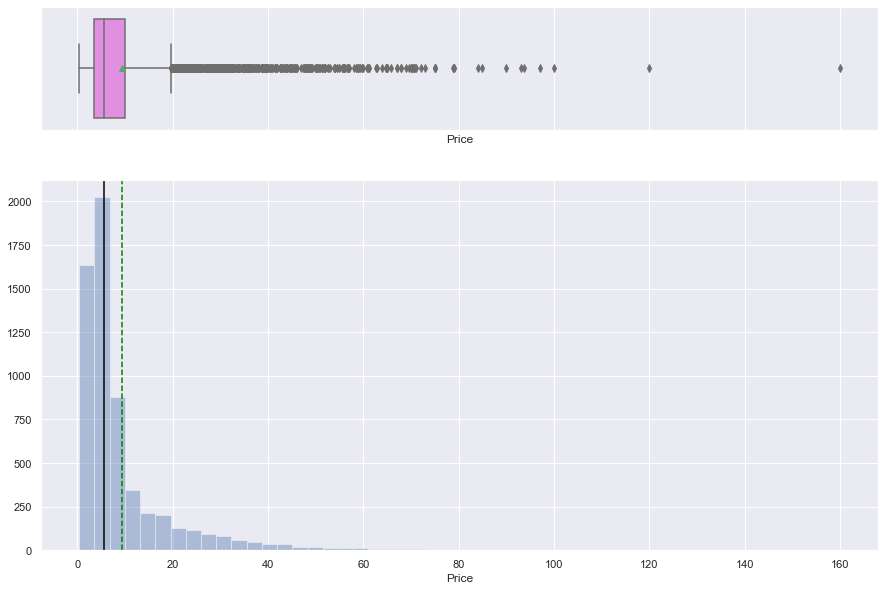

```python
histogram_boxplot(df2["Price"])
```

### Mileage

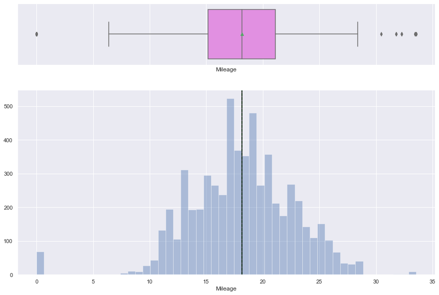

```python
histogram_boxplot(df2["Mileage"])
```

### Power

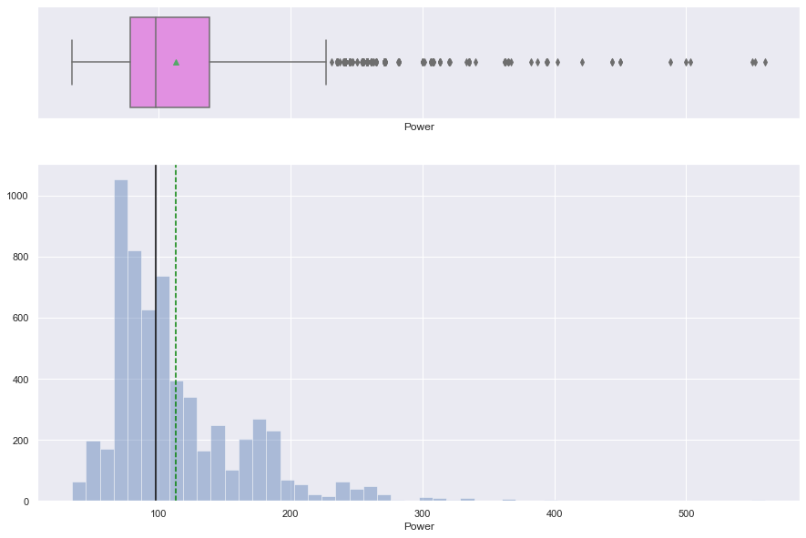

```python
histogram_boxplot(df2["Power"])
```

*Observation: Power of cars (bhp) is also heavily right skewed, there are lot of right outliers.*

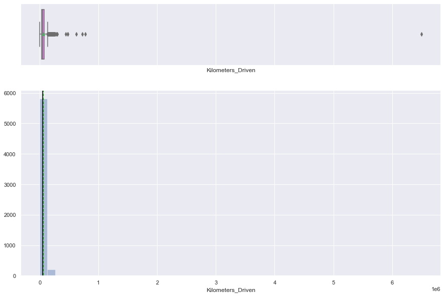

```python
histogram_boxplot(df2["Kilometers_Driven"])
```

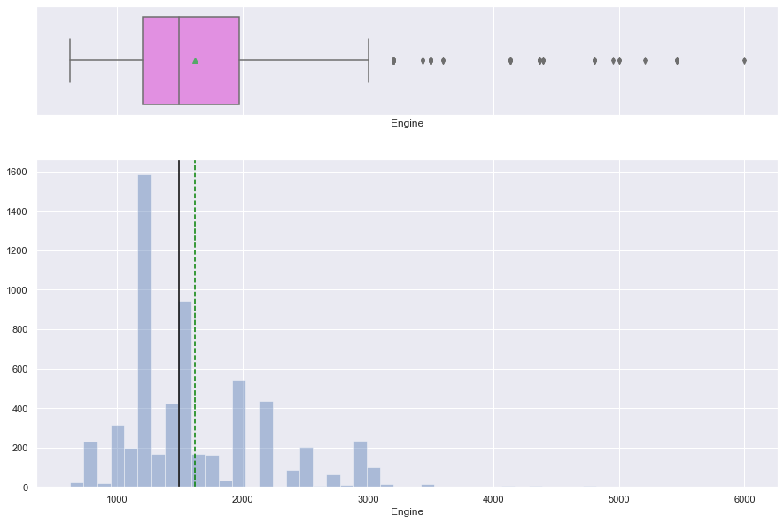

```python
histogram_boxplot(df2["Engine"])
```

```python
# Function to create barplots that indicate percentage for each category.


def perc_on_bar(data, z):
    """
    plot
    feature: categorical feature
    the function won't work if a column is passed in hue parameter
    """

    total = len(data[z])  # length of the column
    plt.figure(figsize=(15, 5))
    plt.xticks(rotation=45)
    ax = sns.countplot(data[z], palette="Paired")
    for p in ax.patches:
        percentage = "{:.1f}%".format(
            100 * p.get_height() / total
        )  # percentage of each class of the category
        x = p.get_x() + p.get_width() / 2 - 0.05  # width of the plot
        y = p.get_y() + p.get_height()  # hieght of the plot

        ax.annotate(percentage, (x, y), size=10)  # annotate the percantage
    plt.show()  # show the plot
```

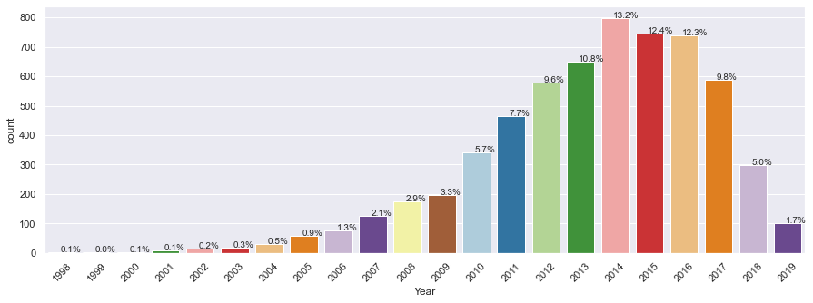

```python
perc_on_bar(df2, "Year")
```

*Observation: Most popular year of make is 2014, also in general upto 5 years old have most sales*

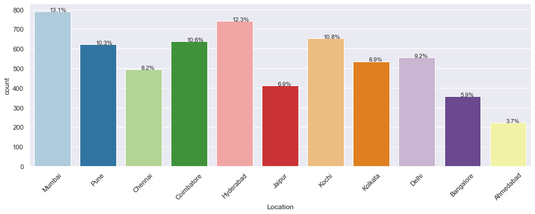

```python
perc_on_bar(df2, "Location")
```

*Observation: Mumbai has the most sales followed by Hyderabad*

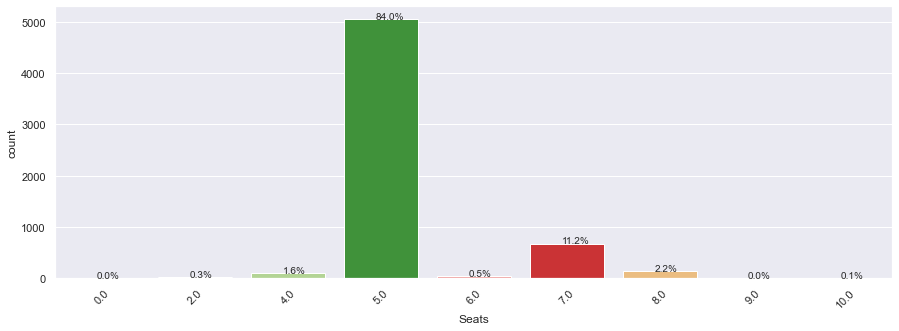

```python
perc_on_bar(df2, "Seats")
```

*Observation: 5 Seater cars have the most sales, followed by 7 seater*

```python
df2.head()
```

|  | Name | Location | Year | Kilometers_Driven | Fuel_Type | Transmission | Owner_Type | Mileage | Engine | Power | Seats | Price |
| --- | --- | --- | --- | --- | --- | --- | --- | --- | --- | --- | --- | --- |
| 0 | Maruti Wagon R LXI CNG | Mumbai | 2010 | 72000 | CNG | Manual | First | 26.60 | 998.0 | 58.16 | 5.0 | 1.75 |
| 1 | Hyundai Creta 1.6 CRDi SX Option | Pune | 2015 | 41000 | Diesel | Manual | First | 19.67 | 1582.0 | 126.20 | 5.0 | 12.50 |
| 2 | Honda Jazz V | Chennai | 2011 | 46000 | Petrol | Manual | First | 18.20 | 1199.0 | 88.70 | 5.0 | 4.50 |
| 3 | Maruti Ertiga VDI | Chennai | 2012 | 87000 | Diesel | Manual | First | 20.77 | 1248.0 | 88.76 | 7.0 | 6.00 |
| 4 | Audi A4 New 2.0 TDI Multitronic | Coimbatore | 2013 | 40670 | Diesel | Automatic | Second | 15.20 | 1968.0 | 140.80 | 5.0 | 17.74 |

## Bivariate Analysis

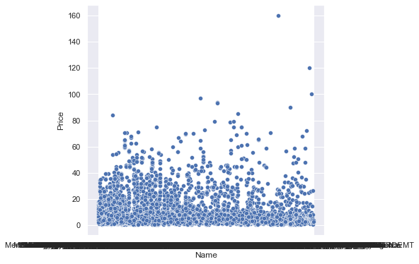

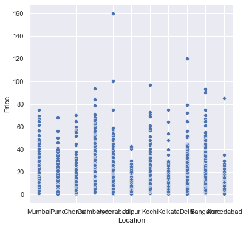

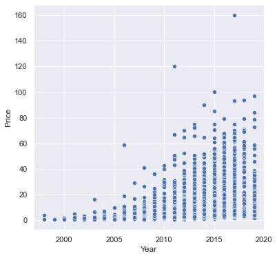

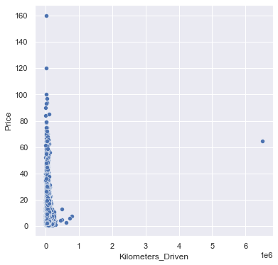

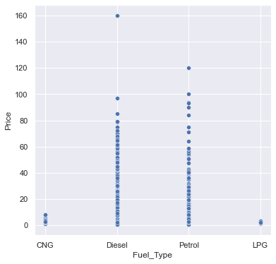

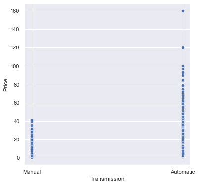

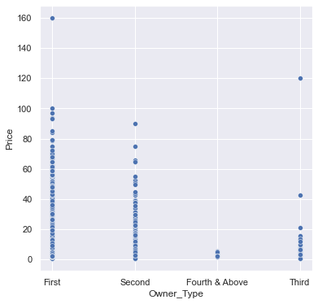

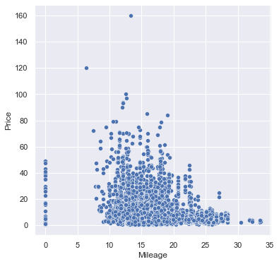

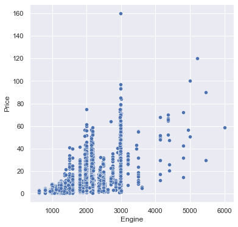

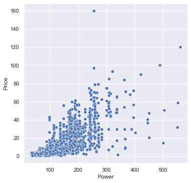

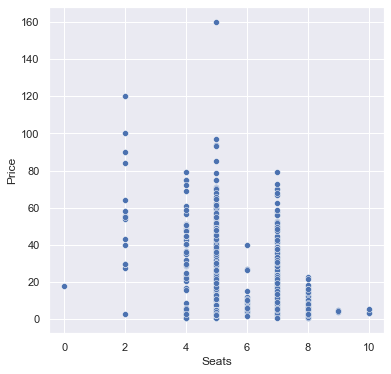

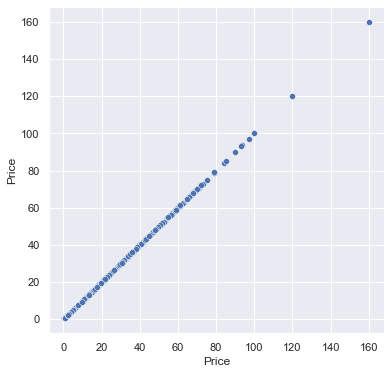

```python
# let's plot the scatterplots of median price with all the features

for i in df2.columns:
    plt.figure(figsize=(6, 6))
    sns.scatterplot(data=df2, x=i, y="Price")
    plt.show()
```

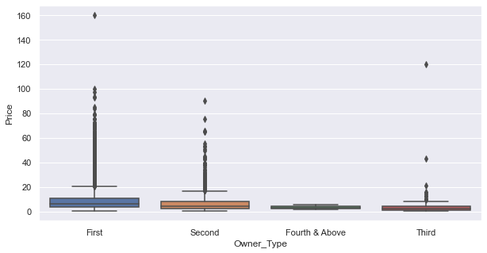

```python
plt.figure(figsize=(10, 5))
sns.boxplot(x="Owner_Type", y="Price", data=df2)
```

*Observation: First and Second Owners have highprices compared to others , but lot of outliers*

```
(array([0, 1]), [Text(0, 0, 'Manual'), Text(1, 0, 'Automatic')])
```

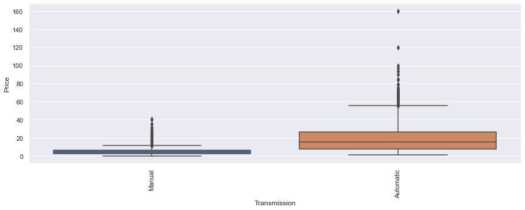

```python
plt.figure(figsize=(15, 5))
sns.boxplot(x="Transmission", y="Price", data=df2)
plt.xticks(rotation=90)
```

*Observation: Automatic Cars are priced at a higher range, compared to Manual transmission*

[output not shown]

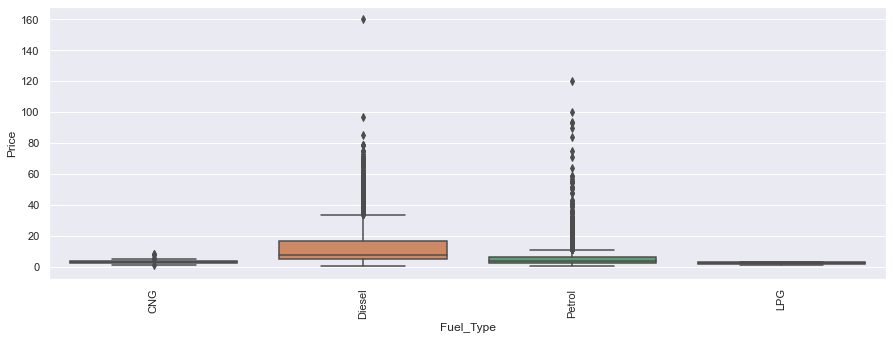

```python
plt.figure(figsize=(15, 5))
sns.boxplot(x="Fuel_Type", y="Price", data=df2)
plt.xticks(rotation=90)
```

*Observation: Diesel vehicles are better priced compared to Petrol (close second) and ahead of CNG and LPG vehicles*

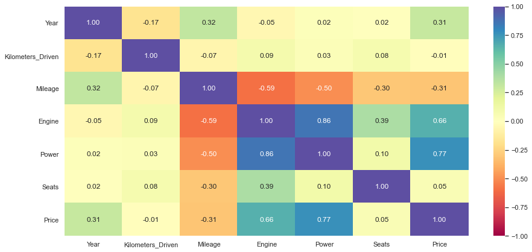

```python
plt.figure(figsize=(15, 7))
sns.heatmap(df2.corr(), annot=True, vmin=-1, vmax=1, fmt=".2f", cmap="Spectral")
plt.show()
```

```python
df2.info()
```

```
<class 'pandas.core.frame.DataFrame'>
Int64Index: 6017 entries, 0 to 6018
Data columns (total 12 columns):
 #   Column             Non-Null Count  Dtype
---  ------             --------------  -----
 0   Name               6017 non-null   object
 1   Location           6017 non-null   object
 2   Year               6017 non-null   int64
 3   Kilometers_Driven  6017 non-null   int64
 4   Fuel_Type          6017 non-null   object
 5   Transmission       6017 non-null   object
 6   Owner_Type         6017 non-null   object
 7   Mileage            6017 non-null   float64
 8   Engine             6017 non-null   float64
 9   Power              6017 non-null   float64
 10  Seats              6017 non-null   float64
 11  Price              6017 non-null   float64
dtypes: float64(5), int64(2), object(5)
memory usage: 740.1+ KB
```

### Checking the numeric columns for skewness

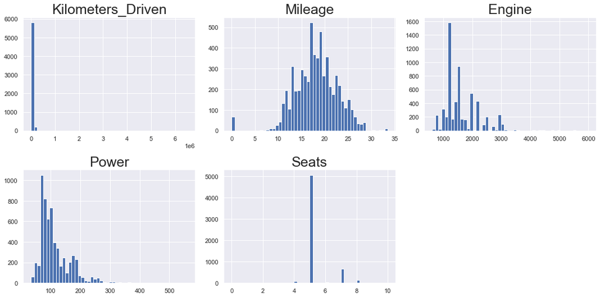

```python
# creating a list of numeric columns
dist_cols = ['Kilometers_Driven', 'Mileage', 'Engine', 'Power','Seats']

# let's plot a histogram of all non-tag columns

plt.figure(figsize=(15, 45))

for i in range(len(dist_cols)):
    plt.subplot(12, 3, i + 1)
    plt.hist(df2[dist_cols[i]], bins=50)
    # sns.histplot(data=df3, x=dist_cols[i], kde=True)  # you can comment the previous line and run this one to get distribution curves
    plt.tight_layout()
    plt.title(dist_cols[i], fontsize=25)

plt.show()
```

```python
# creating a copy of the dataframe
df3 = df2.copy()

# removing contentWarn and studios_colab columns as they have only 0 and 1 values
dist_cols.remove("Mileage")
```

### Checking for skewness after applying log transformation

```python
# using log transforms on some columns

for col in dist_cols:
    df3[col + "_log"] = np.log(df3[col] + 1)

# dropping the original columns
df3.drop(dist_cols, axis=1, inplace=True)
df3.head()
```

|  | Name | Location | Year | Fuel_Type | Transmission | Owner_Type | Mileage | Price | Kilometers_Driven_log | Engine_log | Power_log | Seats_log |
| --- | --- | --- | --- | --- | --- | --- | --- | --- | --- | --- | --- | --- |
| 0 | Maruti Wagon R LXI CNG | Mumbai | 2010 | CNG | Manual | First | 26.60 | 1.75 | 11.184435 | 6.906755 | 4.080246 | 1.791759 |
| 1 | Hyundai Creta 1.6 CRDi SX Option | Pune | 2015 | Diesel | Manual | First | 19.67 | 12.50 | 10.621352 | 7.367077 | 4.845761 | 1.791759 |
| 2 | Honda Jazz V | Chennai | 2011 | Petrol | Manual | First | 18.20 | 4.50 | 10.736418 | 7.090077 | 4.496471 | 1.791759 |
| 3 | Maruti Ertiga VDI | Chennai | 2012 | Diesel | Manual | First | 20.77 | 6.00 | 11.373675 | 7.130099 | 4.497139 | 2.079442 |
| 4 | Audi A4 New 2.0 TDI Multitronic | Coimbatore | 2013 | Diesel | Automatic | Second | 15.20 | 17.74 | 10.613271 | 7.585281 | 4.954418 | 1.791759 |

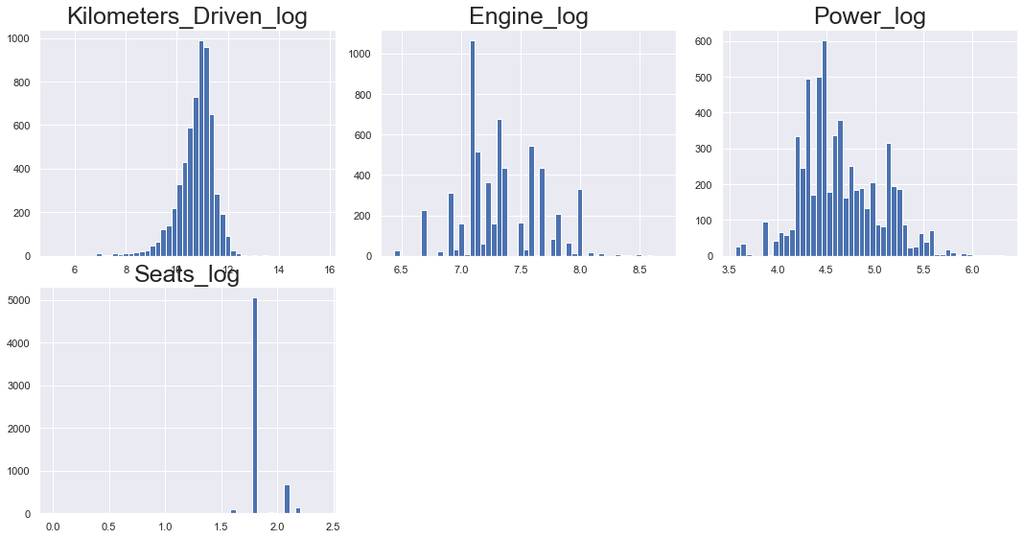

```python
# creating a list of non-tag columns
dist_cols = ['Kilometers_Driven_log', 'Engine_log', 'Power_log','Seats_log']


# let's plot histogram of all non-tag columns

plt.figure(figsize=(15, 45))

for i in range(len(dist_cols)):
    plt.subplot(12, 3, i + 1)
    plt.hist(df3[dist_cols[i]], bins=50)
    # sns.histplot(data=df4, x=dist_cols[i], kde=True)  # you can comment the previous line and run this one to get distribution curves
    plt.tight_layout()
    plt.title(dist_cols[i], fontsize=25)

plt.show()
```

*Observation: Columns have their skewness reduced significantly after log transformation*

### Model Building

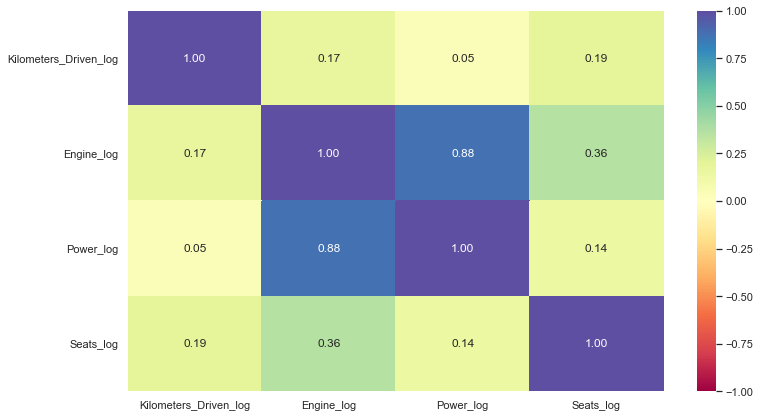

```python
plt.figure(figsize=(12, 7))
sns.heatmap(
    df3[dist_cols].corr(), annot=True, vmin=-1, vmax=1, fmt=".2f", cmap="Spectral"
)
plt.show()
```

*Observation There is a high correlation between Engine and Power log columns, so we can drop Engine column*

#### Dropping Name and Engine_log column

```python
# Dropping Name column as it is not relevant for model building
df3.drop(["Name"], axis=1, inplace=True)
# Dropping Engine_log column as it is highly correlated with Power_log
df3.drop(["Engine_log"], axis=1, inplace=True)
#df3['Seats'] = df['Seats'].astype('category')
df3.info()
```

```
<class 'pandas.core.frame.DataFrame'>
Int64Index: 6017 entries, 0 to 6018
Data columns (total 10 columns):
 #   Column                 Non-Null Count  Dtype
---  ------                 --------------  -----
 0   Location               6017 non-null   object
 1   Year                   6017 non-null   int64
 2   Fuel_Type              6017 non-null   object
 3   Transmission           6017 non-null   object
 4   Owner_Type             6017 non-null   object
 5   Mileage                6017 non-null   float64
 6   Price                  6017 non-null   float64
 7   Kilometers_Driven_log  6017 non-null   float64
 8   Power_log              6017 non-null   float64
 9   Seats_log              6017 non-null   float64
dtypes: float64(5), int64(1), object(4)
memory usage: 646.1+ KB
```

#### Adding a new column as years_old (calculated as 2019 - Year), also dropping the original Year column

```python
df3["years_old"] = 2019 - df["Year"]
df3.drop(["Year"], axis=1, inplace=True)
df3.info()
```

```
<class 'pandas.core.frame.DataFrame'>
Int64Index: 6017 entries, 0 to 6018
Data columns (total 10 columns):
 #   Column                 Non-Null Count  Dtype
---  ------                 --------------  -----
 0   Location               6017 non-null   object
 1   Fuel_Type              6017 non-null   object
 2   Transmission           6017 non-null   object
 3   Owner_Type             6017 non-null   object
 4   Mileage                6017 non-null   float64
 5   Price                  6017 non-null   float64
 6   Kilometers_Driven_log  6017 non-null   float64
 7   Power_log              6017 non-null   float64
 8   Seats_log              6017 non-null   float64
 9   years_old              6017 non-null   int64
dtypes: float64(5), int64(1), object(4)
memory usage: 646.1+ KB
```

### Define dependent and independent variables

```python
ind_vars = df3.drop(["Price"], axis=1) #independent variables, removing Price
dep_var = df3[["Price"]] # Price is a dependent variable
```

### Populate as dummy variables for types object and category

```python
def encode_cat_vars(x):
    x = pd.get_dummies(
        x,
        columns=x.select_dtypes(include=["object", "category"]).columns.tolist(),
        drop_first=True,
    )
    return x


ind_vars_num = encode_cat_vars(ind_vars)
ind_vars_num.head()
```

|  | Mileage | Kilometers_Driven_log | Power_log | Seats_log | years_old | Location_Bangalore | Location_Chennai | Location_Coimbatore | Location_Delhi | Location_Hyderabad | Location_Jaipur | Location_Kochi | Location_Kolkata | Location_Mumbai | Location_Pune | Fuel_Type_Diesel | Fuel_Type_LPG | Fuel_Type_Petrol | Transmission_Manual | Owner_Type_Fourth & Above | Owner_Type_Second | Owner_Type_Third |
| --- | --- | --- | --- | --- | --- | --- | --- | --- | --- | --- | --- | --- | --- | --- | --- | --- | --- | --- | --- | --- | --- | --- |
| 0 | 26.60 | 11.184435 | 4.080246 | 1.791759 | 9 | 0 | 0 | 0 | 0 | 0 | 0 | 0 | 0 | 1 | 0 | 0 | 0 | 0 | 1 | 0 | 0 | 0 |
| 1 | 19.67 | 10.621352 | 4.845761 | 1.791759 | 4 | 0 | 0 | 0 | 0 | 0 | 0 | 0 | 0 | 0 | 1 | 1 | 0 | 0 | 1 | 0 | 0 | 0 |
| 2 | 18.20 | 10.736418 | 4.496471 | 1.791759 | 8 | 0 | 1 | 0 | 0 | 0 | 0 | 0 | 0 | 0 | 0 | 0 | 0 | 1 | 1 | 0 | 0 | 0 |
| 3 | 20.77 | 11.373675 | 4.497139 | 2.079442 | 7 | 0 | 1 | 0 | 0 | 0 | 0 | 0 | 0 | 0 | 0 | 1 | 0 | 0 | 1 | 0 | 0 | 0 |
| 4 | 15.20 | 10.613271 | 4.954418 | 1.791759 | 6 | 0 | 0 | 1 | 0 | 0 | 0 | 0 | 0 | 0 | 0 | 1 | 0 | 0 | 0 | 0 | 1 | 0 |

*Observation: Above is the data set sample we are using for building the model*

### Split the data into train and test (70:30)

```python
from sklearn.model_selection import train_test_split

x_train, x_test, y_train, y_test = train_test_split(
    ind_vars_num, dep_var, test_size=0.3, random_state=1
)
```

```python
print("Number of rows in train data =", x_train.shape[0])
print("Number of rows in test data =", x_test.shape[0])
```

```
Number of rows in train data = 4211
Number of rows in test data = 1806
```

### Fitting the linear model

```python
lin_reg_model = LinearRegression()
lin_reg_model.fit(x_train, y_train)
```

```
LinearRegression()
```

### Calculating the coefficients and Intercept

```python
coef_df = pd.DataFrame(
    np.append(lin_reg_model.coef_.flatten(), lin_reg_model.intercept_),
    index=x_train.columns.tolist() + ["Intercept"],
    columns=["Coefficients"],
)
coef_df
```

|  | Coefficients |
| --- | --- |
| Mileage | -0.316602 |
| Kilometers_Driven_log | -2.723601 |
| Power_log | 14.171137 |
| Seats_log | -9.356891 |
| years_old | -0.696960 |
| Location_Bangalore | 2.076212 |
| Location_Chennai | 1.457235 |
| Location_Coimbatore | 3.106143 |
| Location_Delhi | 0.195529 |
| Location_Hyderabad | 2.590318 |
| Location_Jaipur | 1.397424 |
| Location_Kochi | 0.653856 |
| Location_Kolkata | -1.779813 |
| Location_Mumbai | -1.073339 |
| Location_Pune | 0.818936 |
| Fuel_Type_Diesel | -2.705744 |
| Fuel_Type_LPG | -1.718488 |
| Fuel_Type_Petrol | -6.576571 |
| Transmission_Manual | -3.732590 |
| Owner_Type_Fourth & Above | 0.633391 |
| Owner_Type_Second | -0.407685 |
| Owner_Type_Third | 1.070843 |
| Intercept | 6.017400 |

```python
# Adjusted R^2
def adj_r2(ind_vars, targets, predictions):
    r2 = r2_score(targets, predictions)
    n = ind_vars.shape[0]
    k = ind_vars.shape[1]
    return 1 - ((1 - r2) * (n - 1) / (n - k - 1))


# Model performance check
def model_perf(model, inp, out):

    y_pred = model.predict(inp)
    y_act = out.values

    return pd.DataFrame(
        {
            "RMSE": np.sqrt(mean_squared_error(y_act, y_pred)),
            "MAE": mean_absolute_error(y_act, y_pred),
            "R^2": r2_score(y_act, y_pred),
            "Adjusted R^2": adj_r2(inp, y_act, y_pred),
        },
        index=[0],
    )
```

#### Model Performance Check

```python
# Checking model performance on train set
print("Training Performance\n")
print(model_perf(lin_reg_model, x_train, y_train))

# Checking model performance on test set
print("\n\nTest Performance\n")
print(model_perf(lin_reg_model, x_test, y_test))
```

```
Training Performance

       RMSE       MAE       R^2  Adjusted R^2
0  6.603396  4.238454  0.656887      0.655084


Test Performance

       RMSE       MAE       R^2  Adjusted R^2
0  6.731394  4.122476  0.624767      0.620137
```

**Observations**

- The train and test $R^2$ are 0.65 and 0.62, indicating that the model explains 65% and 62% of the total variation in the train and test sets respectively. Also, both scores are comparable.
- RMSE values on the train and test sets are also comparable.
- MAE indicates that our current model is able to predict prices within a mean error of 4.12 on the test set.

**Conclusions**

- The predictive model that can be used by Cars4U to predict the pricing of a used car in INR Lakhs with an 𝑅2 of 0.65 on the training set.
- Cars4U can use this model to predict the used car prices within a mean error of 4.12 on the test set.
- Following variables have a positive impact on the price of a used car. (from Bi-Variate Analysis)
  - Ownership = First
  - Transmission = Automatic
  - Fuel Type = Diesel